# Рак поджелудочной железы

**Рак поджелудочной железы** — злокачественное новообразование, исходящее из эпителия железистой ткани или протоков поджелудочной железы. В поджелудочной железе различают 2 типа клеток – *экзокринные* и *эндокринные*. Пищеварительный сок вырабатывается *экзокринными* клетками поджелудочной железы, а гормоны (инсулин, глюкагон) вырабатываются *эндокринными* клетками поджелудочной железы. Около **95%** рака поджелудочной железы исходят из экзокринных клеток.  
Вследствие генных мутаций нарушаются следующие клеточные метаболические пути и процессы:

- Ростовой сигналинг:
  - ген **KRAS** – ГТФ-связывающий «молекулярный переключатель», активирующий белки необходимые для распространения факторов роста
- Клеточный цикл:
  - гены семейства **TGF-beta** – цитокины, блокирующие безостановочное деление и запускающий процесс апоптоза
  - нарушение работы циклинов **G1/S** фазы
  - гены, учавствующие в **Wnt** - сигнальном пути, который контролирует скорость пролиферации клеток
- Межклеточная передача информации:
  - гены семейства **NOTCH** – трансмембранные белки-рецепторы, осуществляющие сигнальный путь от клетки к клетке и участвующие в регуляции экспрессии генов
- Ремоделирование хроматина:
  - **SWI/SNF** – семейство белков, участвующих в упаковке ДНК
- Модификация гистонов
- Починка ДНК
- Процессинг РНК

Рак поджелудочной железы является четвертой по частоте причиной смерти от рака в западных странах и, согласно прогнозам, станет второй в течение десятилетия. Каждый год данный тип рака диагностируется у **50,000** человек в США и **18,000** - в России. Поджелудочная аденокарцинома, как правило, имеет очень плохой прогноз: после установления диагноза **25%** людей выживают в течение одного года и менее **5%** - в течение пяти лет. Данный тип рака опасен прежде всего тем, что он не проявляется симптоматически, пока болезнь не достигнет поздних стадий. Поэтому зачастую к моменту выявления заболевания рак поджелудочной железы часто распространяется и на другие части тела.

## Code

```python
# Imports
# adding project folder to lib search path

import pandas as pd
import numpy as np
import os
import sys
import itertools as it
import matplotlib.pyplot as plt
import matplotlib
from scipy import stats

# adding project scripts to lib search path
project = "/".join((os.path.split(os.getcwd())[0], os.path.split(os.getcwd())[1], 'scripts'))
if project not in sys.path:
    sys.path.append(project)

# adding ComBat folder to lib search path
combat = "/".join((os.path.split(os.getcwd())[0], os.path.split(os.getcwd())[1], 'ComBat'))
if combat not in sys.path:
    sys.path.append(combat)


# here we will import ComBat from https://github.com/brentp/combat.py
# which will help us dealing with batch-effect
import combat
import silouhette
```

### Databases

- Загрузка базы данных по эскпрессии генов в **pandas** DataFrame и поиск названия гена по его Ensembl ID:

```python
# creating expression dataframe
exp_data = pd.read_csv('data/expression_table_normalised_icgc.txt', sep="\t")
exp_data.rename(columns={exp_data.columns[0]: 'gene_id'}, inplace=True)
exp_data.head()
```

|  | gene_id | ICGC_0006 | ICGC_0007 | ICGC_0009 | ICGC_0075 | ICGC_0354 | ICGC_0020 | ICGC_0021 | ICGC_0025 | ICGC_0026 | ... | ICGC_0535 | ICGC_0536 | ICGC_0502 | ICGC_0503 | ICGC_0518 | ICGC_0507 | ICGC_0521 | ICGC_0522 | ICGC_0526 | ICGC_0543 |
| --- | --- | --- | --- | --- | --- | --- | --- | --- | --- | --- | --- | --- | --- | --- | --- | --- | --- | --- | --- | --- | --- |
| 0 | ENSG00000000003 | 4.935214 | 5.114459 | 5.375416 | 4.272855 | 3.585551 | 4.728254 | 5.411612 | 5.620586 | 4.817511 | ... | 3.332555 | 4.157640 | 4.483416 | 4.951604 | 3.836224 | 3.972830 | 5.382327 | 4.308381 | 4.732541 | 5.140055 |
| 1 | ENSG00000000419 | 4.034635 | 4.599332 | 4.587680 | 3.472525 | 4.173737 | 4.401976 | 4.386663 | 4.806422 | 4.443624 | ... | 4.601348 | 4.409019 | 3.740030 | 4.300386 | 4.783368 | 3.927274 | 4.001015 | 3.272052 | 4.162536 | 5.284458 |
| 2 | ENSG00000000457 | 3.925488 | 3.907000 | 3.638524 | 4.197544 | 3.757676 | 4.111593 | 3.495744 | 3.551271 | 3.676183 | ... | 3.672093 | 3.511688 | 4.069200 | 3.900946 | 3.947078 | 3.994728 | 4.569100 | 4.477992 | 4.283187 | 3.101123 |
| 3 | ENSG00000000460 | 2.483618 | 2.660843 | 3.214169 | 2.842177 | 3.559219 | 2.621409 | 3.198682 | 4.087306 | 2.686024 | ... | 2.918784 | 2.919825 | 2.932658 | 2.092648 | 3.056026 | 2.653496 | 3.048836 | 3.573936 | 2.998799 | 3.477693 |
| 4 | ENSG00000000938 | 2.484806 | 1.750494 | 2.794076 | 2.353310 | 1.440256 | 3.264178 | 3.445729 | 3.103411 | 2.527272 | ... | 3.614184 | 2.795686 | 1.654626 | 1.726623 | 2.372235 | 1.157676 | 1.311957 | 3.346237 | 2.786160 | 2.123467 |

5 rows × 97 columns

```python
# standartizing rows of our dataset
from sklearn.preprocessing import StandardScaler

matrix_to_scale = exp_data.drop(columns='gene_id').transpose().to_numpy()

scaler = StandardScaler()

matrix_to_scale = scaler.fit_transform(matrix_to_scale)

df = pd.DataFrame(data=matrix_to_scale.T, columns=exp_data.columns[1:])
df.insert(0, 'gene_id', exp_data.gene_id)
df.head()
exp_data = df

exp_data.head()
```

|  | gene_id | ICGC_0006 | ICGC_0007 | ICGC_0009 | ICGC_0075 | ICGC_0354 | ICGC_0020 | ICGC_0021 | ICGC_0025 | ICGC_0026 | ... | ICGC_0535 | ICGC_0536 | ICGC_0502 | ICGC_0503 | ICGC_0518 | ICGC_0507 | ICGC_0521 | ICGC_0522 | ICGC_0526 | ICGC_0543 |
| --- | --- | --- | --- | --- | --- | --- | --- | --- | --- | --- | --- | --- | --- | --- | --- | --- | --- | --- | --- | --- | --- |
| 0 | ENSG00000000003 | 0.504327 | 0.816524 | 1.271040 | -0.649322 | -1.846421 | 0.143859 | 1.334085 | 1.698060 | 0.299320 | ... | -2.287072 | -0.849996 | -0.282582 | 0.532875 | -1.409816 | -1.171886 | 1.283078 | -0.587446 | 0.151327 | 0.861105 |
| 1 | ENSG00000000419 | -1.103992 | 0.220289 | 0.192964 | -2.422208 | -0.777783 | -0.242533 | -0.278445 | 0.705940 | -0.144865 | ... | 0.225016 | -0.226016 | -1.794876 | -0.480775 | 0.651876 | -1.355767 | -1.182835 | -2.892340 | -0.804050 | 1.826991 |
| 2 | ENSG00000000457 | -0.195756 | -0.234676 | -0.799864 | 0.376967 | -0.549029 | 0.196026 | -1.100438 | -0.983546 | -0.720586 | ... | -0.729195 | -1.066875 | 0.106782 | -0.247421 | -0.150306 | -0.049993 | 1.159155 | 0.967358 | 0.557260 | -1.931182 |
| 3 | ENSG00000000460 | -1.042803 | -0.626951 | 0.671402 | -0.201459 | 1.481047 | -0.719484 | 0.635064 | 2.720180 | -0.567866 | ... | -0.021705 | -0.019262 | 0.010849 | -1.960197 | 0.300328 | -0.644191 | 0.283455 | 1.515579 | 0.166046 | 1.289750 |
| 4 | ENSG00000000938 | 0.194345 | -0.764832 | 0.598321 | 0.022582 | -1.170073 | 1.212381 | 1.449527 | 1.002383 | 0.249815 | ... | 1.669567 | 0.600425 | -0.890057 | -0.796013 | 0.047302 | -1.539186 | -1.337660 | 1.319568 | 0.587981 | -0.277646 |

5 rows × 97 columns

```python
# gene names and ids table which was given
name_id_table = pd.read_csv('data/ensembl_table', sep="\t")
name_id_table.head()
```

|  | #id | gene | chrom | chromStart | chromEnd | strand |
| --- | --- | --- | --- | --- | --- | --- |
| 0 | ENSG00000111671 | SPSB2 | chr12 | 6980098 | 6998522 | - |
| 1 | ENSG00000110514 | MADD | chr11 | 47290711 | 47351582 | + |
| 2 | ENSG00000086015 | MAST2 | chr1 | 46252658 | 46501796 | + |
| 3 | ENSG00000255071 | SAA2-SAA4 | chr11 | 18252969 | 18270182 | - |
| 4 | ENSG00000169740 | ZNF32 | chr10 | 44139306 | 44144304 | - |

```python
# gene names and ids table from ensembl martview
name_id_table_mart = pd.read_csv('data/mart_export_gene_name.txt')

rename_dict = dict(zip(list(name_id_table_mart.columns.values), ['gene_id', 'gene_id_v', 'gene_name']))
name_id_table_mart.rename(columns = rename_dict, inplace=True)
name_id_table_mart.head()
```

|  | gene_id | gene_id_v | gene_name |
| --- | --- | --- | --- |
| 0 | ENSG00000210049 | ENSG00000210049.1 | MT-TF |
| 1 | ENSG00000211459 | ENSG00000211459.2 | MT-RNR1 |
| 2 | ENSG00000210077 | ENSG00000210077.1 | MT-TV |
| 3 | ENSG00000210082 | ENSG00000210082.2 | MT-RNR2 |
| 4 | ENSG00000209082 | ENSG00000209082.1 | MT-TL1 |

```python
# for-loop to find out gene names for given ids
# note: this loop is here, because for some genes there are no names,
# so we will call such genes as 'broken_gene'
gene_names = []
broken_genes = []

for gene_id in exp_data.gene_id:
    try:
        gene_names.append(name_id_table.loc[name_id_table['#id'] == gene_id].gene.values[0])
    except:
        try:
            gene_names.append(name_id_table_mart.loc[name_id_table_mart['gene_id'] == gene_id].gene_name.values[0])
        except:
            gene_names.append('missing_gene')
            broken_genes.append(gene_id)
```

```python
# inserting gene names into our dataframe
exp_data.insert(1, 'gene_name', gene_names)
```

```python
# our database
exp_data.head()
```

|  | gene_id | gene_name | ICGC_0006 | ICGC_0007 | ICGC_0009 | ICGC_0075 | ICGC_0354 | ICGC_0020 | ICGC_0021 | ICGC_0025 | ... | ICGC_0535 | ICGC_0536 | ICGC_0502 | ICGC_0503 | ICGC_0518 | ICGC_0507 | ICGC_0521 | ICGC_0522 | ICGC_0526 | ICGC_0543 |
| --- | --- | --- | --- | --- | --- | --- | --- | --- | --- | --- | --- | --- | --- | --- | --- | --- | --- | --- | --- | --- | --- |
| 0 | ENSG00000000003 | TSPAN6 | 0.504327 | 0.816524 | 1.271040 | -0.649322 | -1.846421 | 0.143859 | 1.334085 | 1.698060 | ... | -2.287072 | -0.849996 | -0.282582 | 0.532875 | -1.409816 | -1.171886 | 1.283078 | -0.587446 | 0.151327 | 0.861105 |
| 1 | ENSG00000000419 | DPM1 | -1.103992 | 0.220289 | 0.192964 | -2.422208 | -0.777783 | -0.242533 | -0.278445 | 0.705940 | ... | 0.225016 | -0.226016 | -1.794876 | -0.480775 | 0.651876 | -1.355767 | -1.182835 | -2.892340 | -0.804050 | 1.826991 |
| 2 | ENSG00000000457 | SCYL3 | -0.195756 | -0.234676 | -0.799864 | 0.376967 | -0.549029 | 0.196026 | -1.100438 | -0.983546 | ... | -0.729195 | -1.066875 | 0.106782 | -0.247421 | -0.150306 | -0.049993 | 1.159155 | 0.967358 | 0.557260 | -1.931182 |
| 3 | ENSG00000000460 | C1orf112 | -1.042803 | -0.626951 | 0.671402 | -0.201459 | 1.481047 | -0.719484 | 0.635064 | 2.720180 | ... | -0.021705 | -0.019262 | 0.010849 | -1.960197 | 0.300328 | -0.644191 | 0.283455 | 1.515579 | 0.166046 | 1.289750 |
| 4 | ENSG00000000938 | FGR | 0.194345 | -0.764832 | 0.598321 | 0.022582 | -1.170073 | 1.212381 | 1.449527 | 1.002383 | ... | 1.669567 | 0.600425 | -0.890057 | -0.796013 | 0.047302 | -1.539186 | -1.337660 | 1.319568 | 0.587981 | -0.277646 |

5 rows × 98 columns

**Note**: не для всех генов есть название по ID в таблице из задания и в таблице biomart ENSEMBL, поэтому дадим таким генам название **"missing_gene"**.

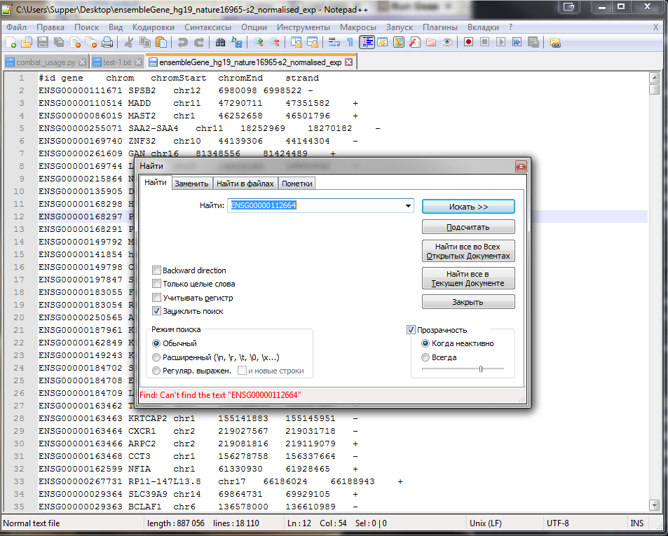

```python
from IPython.display import Image
Image(filename='img/broken_name.png')
```

```python
exp_data.loc[exp_data['gene_name'] == 'missing_gene'].head()
```

|  | gene_id | gene_name | ICGC_0006 | ICGC_0007 | ICGC_0009 | ICGC_0075 | ICGC_0354 | ICGC_0020 | ICGC_0021 | ICGC_0025 | ... | ICGC_0535 | ICGC_0536 | ICGC_0502 | ICGC_0503 | ICGC_0518 | ICGC_0507 | ICGC_0521 | ICGC_0522 | ICGC_0526 | ICGC_0543 |
| --- | --- | --- | --- | --- | --- | --- | --- | --- | --- | --- | --- | --- | --- | --- | --- | --- | --- | --- | --- | --- | --- |
| 3714 | ENSG00000112664 | missing_gene | 1.556191 | -0.622104 | 2.196993 | -1.568836 | -1.985454 | 1.068935 | 1.977844 | 0.198554 | ... | -0.477543 | 0.069055 | -0.431235 | -0.032527 | -0.063051 | -0.166284 | -0.269080 | -1.252923 | -0.699529 | 1.718492 |
| 4540 | ENSG00000120087 | missing_gene | -0.872683 | -0.914996 | -0.761057 | -0.841188 | 0.653412 | -0.936068 | 0.473775 | 0.790532 | ... | -1.644838 | -0.945679 | 0.984525 | -0.081279 | -3.075350 | -0.051627 | 1.373164 | -0.722394 | 0.374945 | -0.862413 |
| 4650 | ENSG00000121083 | missing_gene | -0.385840 | -1.015870 | -1.692411 | -0.303245 | -0.653633 | -1.662685 | -2.247344 | 0.742640 | ... | 0.221564 | 0.101694 | -0.936288 | 0.772120 | -0.620306 | 0.409508 | 1.520386 | -3.440693 | 1.229385 | 1.045581 |
| 5310 | ENSG00000127688 | missing_gene | -2.716478 | -0.007165 | -0.302585 | -1.065336 | 1.642318 | -0.302288 | 0.360311 | -0.412654 | ... | -0.399566 | -0.915901 | 1.018457 | -0.699689 | 0.903706 | 0.152210 | 2.326180 | 1.725791 | -2.039257 | 0.475875 |
| 6987 | ENSG00000139617 | missing_gene | 0.079713 | -0.897957 | -1.231920 | -3.059774 | 1.926848 | 0.921679 | -0.569017 | 1.014694 | ... | 0.589105 | 0.985994 | 0.939599 | 0.793626 | 0.383733 | 1.465301 | 1.619127 | 0.952459 | -0.609736 | 0.014734 |

5 rows × 98 columns

### Duplicates

- На всякий случай проверим, есть ли у нас гены-дупликаты (т.е. гены с одиннаковой экспрессией по всем образцам):

```python
# search duplicates
ser = exp_data.duplicated(exp_data.columns[2:])
id_ = ser.loc[ser == True].index

exp_data.iloc[id_][:5]
```

|  | gene_id | gene_name | ICGC_0006 | ICGC_0007 | ICGC_0009 | ICGC_0075 | ICGC_0354 | ICGC_0020 | ICGC_0021 | ICGC_0025 | ... | ICGC_0535 | ICGC_0536 | ICGC_0502 | ICGC_0503 | ICGC_0518 | ICGC_0507 | ICGC_0521 | ICGC_0522 | ICGC_0526 | ICGC_0543 |
| --- | --- | --- | --- | --- | --- | --- | --- | --- | --- | --- | --- | --- | --- | --- | --- | --- | --- | --- | --- | --- | --- |
| 14318 | ENSG00000198444 | F8A2 | 0.153270 | 0.502802 | -0.806818 | 0.057425 | 0.824917 | -0.633385 | 1.256817 | 1.048709 | ... | -1.119711 | 0.356126 | 0.767485 | 0.767455 | 1.266465 | 0.869327 | -1.717159 | 0.257343 | -1.717159 | 0.391447 |
| 14554 | ENSG00000201750 | missing_gene | -1.777271 | 0.272009 | 0.619224 | 0.535351 | 0.989859 | 0.156577 | 0.651998 | 1.167856 | ... | 0.540236 | 0.047202 | -0.328036 | -1.856329 | 1.191869 | -0.218271 | -1.802024 | 0.851957 | -1.802024 | 1.097424 |
| 14628 | ENSG00000203852 | HIST2H3A | -1.827160 | 1.728192 | -0.106749 | -0.456223 | 0.517849 | -1.202249 | 0.380288 | 0.094623 | ... | -0.133275 | -0.921977 | -0.391270 | -1.213806 | -0.563686 | -2.044207 | -1.291662 | -0.547998 | 0.662921 | 1.626453 |
| 14966 | ENSG00000206596 | RNU1-27P | 2.812057 | 0.714207 | -0.029578 | 2.036666 | 0.773355 | -0.422207 | -0.564769 | -1.321526 | ... | -0.413236 | -0.508006 | 0.599475 | 0.006253 | -0.319397 | -0.319847 | -0.529511 | 0.768707 | -1.334130 | -0.688796 |
| 14971 | ENSG00000206652 | RNU1-1 | 2.812057 | 0.714207 | -0.029578 | 2.036666 | 0.773355 | -0.422207 | -0.564769 | -1.321526 | ... | -0.413236 | -0.508006 | 0.599475 | 0.006253 | -0.319397 | -0.319847 | -0.529511 | 0.768707 | -1.334130 | -0.688796 |

5 rows × 98 columns

- Для окончательной подготовки нашего датасета мы уберём гены-дупликаты.

### Final table

```python
# taking part from exp_data where won't be 'broken_gene' and deleting duplicates

# we can take only take "not broken" genes

expression_dataframe = exp_data.drop(axis=0, index=id_).loc[exp_data['gene_name'] != 'missing_gene']

# or all of them
#expression_dataframe = exp_data.drop(axis=0, index=id_)

print(exp_data.shape)
print(expression_dataframe.shape)
```

```
(18278, 98)
(18094, 98)
```

#### Annotation

- В статье "Genomic analyses identify molecular subtypes of pancreatic cancer" P. Bailey et al. авторы выделили 4 подтипа рака поджелудочной железы:
  - **Сквамозный** - опухоли данного подтипа характерны насыщенностью мутаций в генах *TP53* и *KDM6A*, изменением экспрессии TP63deltaN и выключением генов, контролирующих апоптоз клетки, с помощью гиперметилирования. Прогноз выживаемости пациента с данным типом рака очень плохой (что мы увидим дальше).
  - **Иммуногенный** - в опухолях такого подтипа активированы иммунные системы, включая те, что вовлечены в угнетение иммунитета.
  - **Прогениторный** - клетки в опухолях данного подтипа рака гиперэкспрессируют гены, вовлеченные в раннее развитие поджелудочной железы (*FOXA2/3, PDX1, MNX1*).
  - **Аберрантный** - при таком типе рака нарушается дифференциация эндокринных (*NEUROD1, NKX2-2*) и экзокринных клеток (*NR5A2, RBPJL*), также нарушается регуляция генов, вовлеченных в системы активации гена *KRAS*
- Загрузим таблицу с аннотацией по пациентам и подсчитаем количество пациентов по подтипам рака:

```python
# loading annotation (sample - cancer subtype) table for our task
annotation_table = pd.read_csv('data/annotation_table.txt', sep="\t", names = ['icgc_id', 'subtype'], header=0)

annotation_table.head()
```

|  | icgc_id | subtype |
| --- | --- | --- |
| 0 | ICGC_0543 | Squamous |
| 1 | ICGC_0522 | Squamous |
| 2 | ICGC_0521 | Squamous |
| 3 | ICGC_0535 | Squamous |
| 4 | ICGC_0313 | Squamous |

```python
# printing counts for each cancer subtype
subtype_lst = set(list(annotation_table.subtype))

print('[Subtype]: [number of samples]')

for subtype in subtype_lst:
    num_samples = len(annotation_table.loc[annotation_table['subtype'] == subtype].values)
    print(f'{subtype}: {num_samples}')
```

```
[Subtype]: [number of samples]
Pancreatic Progenitor: 30
Squamous: 25
ADEX: 16
Immunogenic: 25
```

```python
# finding out cancer subtype for each sample
samples_data = expression_dataframe.columns[2:]
samples_subtype = [annotation_table.loc[annotation_table.icgc_id == sample].subtype.values[0] for sample in samples_data]
```

#### Batch-effect

- Исследование наличия в данных batch-effect - очень трудный процесс. Так как у нас нет данных о том, была ли уже проведена корректировка батчей и какие данные поступили из каких лабораторий, мы не сможем изначально задать батчи, по которым можно было бы запустить, например, ComBat, чтобы наверняка убрать батч-эффект.
- Для проверки на батч-эффект мы сначала построим график t-SNE, чтобы проверить выделяются ли какие-нибудь данные в батчи.

```python
# importing
from sklearn.manifold import TSNE
```

```python
# making transposed dataframe
exp_T = expression_dataframe.transpose().reset_index()
exp_T = exp_T.rename(columns=exp_T.iloc[0])
exp_T = exp_T.drop(index=[0,1]).reset_index().drop(columns='index')

# returning subtype names for easier understanding
exp_T.insert(1, column='subtype', value = samples_subtype)

# samples
Y_data = list(expression_dataframe.columns)[2:]

# we have samples data in samples_data (just reminder)
samples_data = exp_T.gene_id
matrix = exp_T.to_numpy()[:, 2:]
#matrix = matrix_to_scale
```

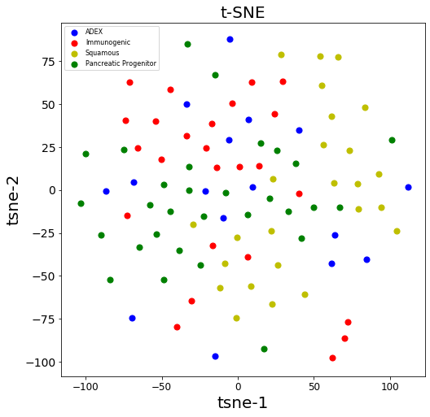

```python
# t-SNE composition
tsne_X = TSNE(n_components=2).fit_transform(matrix)

# We will make helpful dataframe
tsne_df = pd.DataFrame(data = tsne_X, columns=['tsne_1', 'tsne_2'])

tsne_Y = [annotation_table.loc[annotation_table.icgc_id == sample].subtype.values[0] for sample in Y_data]

tsne_df.insert(0, 'subtype', tsne_Y)
#pca_df.insert(0, 'samples',

# plotting t-SNE
plt.figure()
plt.figure(figsize=(8,8))
plt.xticks(fontsize=12)
plt.yticks(fontsize=14)
plt.xlabel('tsne-1',fontsize=20)
plt.ylabel('tsne-2',fontsize=20)
plt.title("t-SNE",fontsize=20)
plt.tick_params(axis='x')
plt.tick_params(axis='y')
targets = ['ADEX', 'Immunogenic', 'Squamous', 'Pancreatic Progenitor']
colors = ['b', 'r', 'y', 'g']
for target, color in zip(targets,colors):
    indicesToKeep = tsne_df['subtype'] == target
    plt.scatter(tsne_df.loc[indicesToKeep, 'tsne_1']
               , tsne_df.loc[indicesToKeep, 'tsne_2'], c = color, s = 50)

plt.legend(targets,prop={'size': 8})
plt.show()
```

- Так как t-SNE - стохастический процесс, то построить его нужно несколько раз. После нескольких (сотен) построений было выявлено, что все подтипы рака склонны к группированию, однако не понятно является ли это батч-эффектом или тем, что исследователи из статьи правильно разделили подтипы.
- Мы можем также использовать кластеризацию. Если образцы кластеризуются так, как они были разделены по под типам рака в статье, то мы сможем сделать вывод: влияние батч-эффекта незначительно на наших данных, иначе можно провести, к примеру, нормализацию данных с помощью ComBat по выявленным при кластеризации батчам.
- Для построения кластеризации мы воспользуемся AgglomerativeClustering из пакета sklearn:

```python
# importing
from sklearn.cluster import AgglomerativeClustering
from sklearn.metrics import silhouette_score
from sklearn.metrics import silhouette_samples
import sklearn.decomposition
from sklearn.datasets import make_classification
from sklearn.cluster import Birch
from matplotlib import pyplot

matplotlib.rc('axes',edgecolor='black')
```

**Note**: для иллюстрации кластеризации мы будем использовать PCA plot.

```python
# Preparing data for PCA
X_data = expression_dataframe.to_numpy()[:, 2:]
X_data = X_data.T

# Preparing Ys for pca-plot
Y_data = list(expression_dataframe.columns)[2:]
```

```python
# Making composition
pca_composition = sklearn.decomposition.PCA(n_components=2)

pca_X = pca_composition.fit_transform(X_data)
pca_Y = [annotation_table.loc[annotation_table.icgc_id == sample].subtype.values[0] for sample in Y_data]

# We will make helpful dataframe
pca_df = pd.DataFrame(data = pca_X, columns=['pca_1', 'pca_2'])

pca_df.insert(0, 'subtype', pca_Y)
```

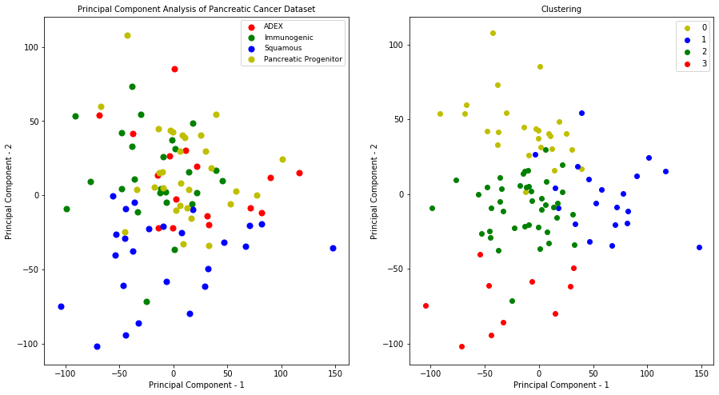

```python
# agglomerative clustering
# define the model
#model = Birch(threshold = 0.1, n_clusters=4)
model = AgglomerativeClustering(n_clusters=4)
# fit model and predict clusters
yhat = model.fit_predict(matrix)

fig, (ax2, ax1) = plt.subplots(1, 2, figsize=(15,8))

# PCA plot for data
ax2.set_xlabel('Principal Component - 1')
ax2.set_ylabel('Principal Component - 2')
ax2.set_title("Principal Component Analysis of Pancreatic Cancer Dataset",fontsize=10)
ax2.tick_params(axis='x')
ax2.tick_params(axis='y')

targets = ['ADEX', 'Immunogenic', 'Squamous', 'Pancreatic Progenitor']
colors = ['r', 'g', 'b', 'y']

for target, color in zip(targets,colors):
    indicesToKeep = pca_df['subtype'] == target
    ax2.scatter(pca_df.loc[indicesToKeep, 'pca_1']
               , pca_df.loc[indicesToKeep, 'pca_2'], c = color, s = 50)

ax2.legend(targets,prop={'size': 9})

ax1.set_xlabel('Principal Component - 1')
ax1.set_ylabel('Principal Component - 2')
ax1.set_title('Clustering', fontsize=10)
ax1.tick_params(axis='x')
ax1.tick_params(axis='y')

# retrieve unique clusters
clusters = np.unique(yhat)
colors = ['y', 'b', 'g', 'r', 'm', 'c']
# create scatter plot for samples from each cluster
for cluster, color in zip(clusters, colors):
    # get row indexes for samples with this cluster
    row_ix = np.where(yhat == cluster)
    # create scatter of these samples
    ax1.scatter(pca_X[row_ix, 0], pca_X[row_ix, 1], color=color, label=cluster)
# show the plot
ax1.legend()
plt.show()
```

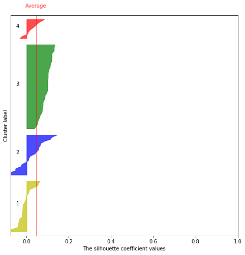

```python
# silhoutte plot for clasterization
plt.figure(figsize=(8,8))
silouhette.silhouette_plot(matrix, yhat, colors, n_clusters=4)
plt.show()
```

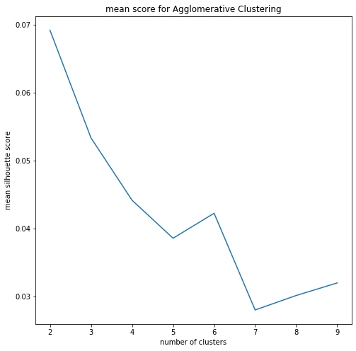

```python
# let's graph silouhette score from number of clusters
res = []

n_clusters = [n for n in range(2, 10)]

for n in n_clusters:
    model = AgglomerativeClustering(n_clusters=n)
    # fit model and predict clusters
    y_hat_n = model.fit_predict(matrix)
    res.append(silhouette_score(matrix, y_hat_n))

plt.figure(figsize=(8,8))
plt.xlabel('number of clusters', fontsize=10)
plt.ylabel('mean silhouette score', fontsize=10)
plt.title('mean score for Agglomerative Clustering')
plt.plot(n_clusters, res)
plt.show()
```

- По нескольким попыткам кластеризации было выявленно, что образцы не кластеризуются в свои подтипы рака, напротив появились межподтипные кластеры. Что говорит о том, что в данных может присутствовать батч-эффект.
- На данных кластерах мы используем ComBat:

```python
yhat
```

```
array([1, 0, 3, 1, 1, 2, 2, 3, 2, 2, 1, 2, 1, 1, 0, 1, 2, 2, 2, 2, 2, 0,
       0, 2, 0, 0, 0, 2, 2, 2, 3, 2, 2, 2, 2, 2, 2, 3, 3, 2, 3, 2, 1, 0,
       1, 2, 2, 2, 0, 0, 0, 1, 1, 3, 2, 3, 2, 0, 1, 2, 1, 2, 0, 2, 2, 0,
       0, 0, 0, 0, 0, 2, 2, 0, 0, 2, 1, 3, 0, 0, 1, 2, 0, 2, 2, 1, 2, 2,
       1, 2, 2, 1, 1, 1, 0, 3], dtype=int64)
```

```python
##### using ComBat

# creating batch list with class numbers to create batches for ComBat
batches = yhat

# taking naked our dataframe to use combat on it
df_before_combat = expression_dataframe.drop(columns=['gene_name', 'gene_id'])

# some magic for columns names -_-
df_before_combat.columns = [i for i in range(96)]

# using ComBat
df_after_combat = combat.combat(df_before_combat, batches)

# deleting
del df_before_combat
```

```
found 4 batches
found 0 numerical covariates...
found 0 categorical variables:
Standardizing Data across genes.
Fitting L/S model and finding priors
Finding parametric adjustments
```

```
Adjusting data
```

- Построим t-SNE ещё раз:

```python
# making transposed dataframe
matrix = df_after_combat.transpose().to_numpy()
```

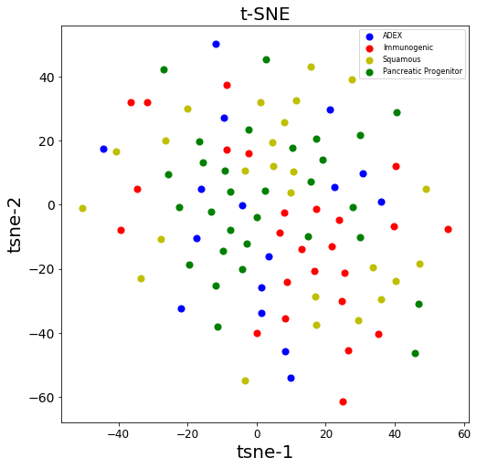

```python
# t-SNE composition
tsne_X = TSNE(n_components=2).fit_transform(matrix)

# We will make helpful dataframe
tsne_df = pd.DataFrame(data = tsne_X, columns=['tsne_1', 'tsne_2'])

tsne_Y = [annotation_table.loc[annotation_table.icgc_id == sample].subtype.values[0] for sample in Y_data]

tsne_df.insert(0, 'subtype', tsne_Y)
#pca_df.insert(0, 'samples',

# plotting t-SNE
plt.figure()
plt.figure(figsize=(8,8))
plt.xticks(fontsize=12)
plt.yticks(fontsize=14)
plt.xlabel('tsne-1',fontsize=20)
plt.ylabel('tsne-2',fontsize=20)
plt.title("t-SNE",fontsize=20)
plt.tick_params(axis='x')
plt.tick_params(axis='y')
targets = ['ADEX', 'Immunogenic', 'Squamous', 'Pancreatic Progenitor']
colors = ['b', 'r', 'y', 'g']
for target, color in zip(targets,colors):
    indicesToKeep = tsne_df['subtype'] == target
    plt.scatter(tsne_df.loc[indicesToKeep, 'tsne_1']
               , tsne_df.loc[indicesToKeep, 'tsne_2'], c = color, s = 50)

plt.legend(targets,prop={'size': 8})
plt.show()
```

- Наши данные стали ещё сильнее разбрасываться t-SNE. Это говорит о том, что сейчас в данных влияние батч-эффекта не очень сильное.

```python
# making new dataframe
genes = expression_dataframe.gene_id
gen_names = expression_dataframe.gene_name
col = expression_dataframe.columns
expression_dataframe = df_after_combat
expression_dataframe.insert(0, 'gene_names', gen_names)
expression_dataframe.insert(0, 'gene_id', genes)
```

```python
# renaming colums
rename_dict = dict(zip(list(expression_dataframe.columns.values), list(col)))
expression_dataframe.rename(columns=rename_dict, inplace=True)
expression_dataframe.head()
```

|  | gene_id | gene_name | ICGC_0006 | ICGC_0007 | ICGC_0009 | ICGC_0075 | ICGC_0354 | ICGC_0020 | ICGC_0021 | ICGC_0025 | ... | ICGC_0535 | ICGC_0536 | ICGC_0502 | ICGC_0503 | ICGC_0518 | ICGC_0507 | ICGC_0521 | ICGC_0522 | ICGC_0526 | ICGC_0543 |
| --- | --- | --- | --- | --- | --- | --- | --- | --- | --- | --- | --- | --- | --- | --- | --- | --- | --- | --- | --- | --- | --- |
| 0 | ENSG00000000003 | TSPAN6 | 0.719672 | 0.898425 | 0.876724 | -0.444656 | -1.652837 | 0.049362 | 1.266628 | 1.348228 | ... | -2.436795 | -0.967072 | -0.074521 | 0.447215 | -1.539609 | -0.972057 | 1.505632 | -0.382207 | 0.305027 | 0.424084 |
| 1 | ENSG00000000419 | DPM1 | -0.372250 | 0.039398 | -0.213266 | -1.647940 | -0.056565 | -0.395088 | -0.435238 | 0.248129 | ... | 0.127623 | -0.376623 | -1.040846 | -0.661438 | 0.604845 | -0.615903 | -0.448550 | -2.102905 | -0.860586 | 1.256456 |
| 2 | ENSG00000000457 | SCYL3 | -0.206666 | -0.706983 | -0.063754 | 0.371828 | -0.563500 | 0.284865 | -0.977066 | -0.241109 | ... | -0.615711 | -0.944396 | 0.098920 | -0.146770 | -0.052241 | -0.059435 | 1.161899 | 0.968169 | 0.086981 | -1.156101 |
| 3 | ENSG00000000460 | C1orf112 | -1.012238 | -0.562730 | -0.154680 | -0.136143 | 1.615857 | -0.599519 | 0.789223 | 1.584299 | ... | 0.115874 | 0.118380 | 0.084934 | -1.871554 | 0.446037 | -0.597162 | 0.368800 | 1.651815 | 0.193961 | 0.370166 |
| 4 | ENSG00000000938 | FGR | 0.541946 | -0.569673 | 0.054949 | 0.375489 | -0.780323 | 1.064343 | 1.297771 | 0.521602 | ... | 1.514363 | 0.461978 | -0.508957 | -0.912571 | -0.082475 | -1.138034 | -0.942733 | 1.632410 | 0.729194 | -0.956707 |

5 rows × 98 columns

### PCA

```python
import sklearn.decomposition
matplotlib.rc('axes',edgecolor='black')
```

```python
# making transposed dataframe
exp_T = expression_dataframe.transpose().reset_index()
exp_T = exp_T.rename(columns=exp_T.iloc[0])
exp_T = exp_T.drop(index=[0,1]).reset_index().drop(columns='index')

# returning subtype names for easier understanding
exp_T.insert(1, column='subtype', value = samples_subtype)

# samples labels
Y_data = list(exp_T.subtype)

# matrix for PCA
X_data = exp_T.to_numpy()[:, 2:]
```

```python
# Making composition
pca_composition = sklearn.decomposition.PCA(n_components=2)

pca_X = pca_composition.fit_transform(X_data)
pca_Y = Y_data

pca_composition.explained_variance_ratio_
```

```
array([0.0782228 , 0.06649516])
```

```python
# We will make helpful dataframe
pca_df = pd.DataFrame(data = pca_X, columns=['pca_1', 'pca_2'])

pca_df.insert(0, 'subtype', pca_Y)
#pca_df.insert(0, 'samples',
```

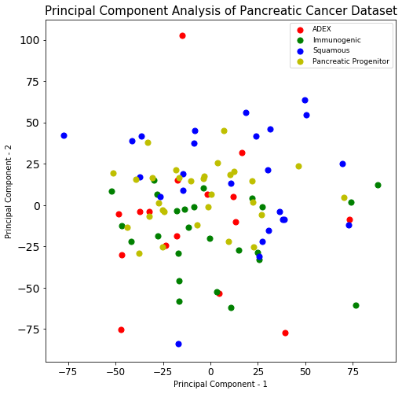

```python
# plotting
figure = plt.figure(figsize=(8,8))
plt.xticks(fontsize=12)
plt.yticks(fontsize=14)
plt.xlabel('Principal Component - 1',fontsize=10)
plt.ylabel('Principal Component - 2',fontsize=10)
plt.title("Principal Component Analysis of Pancreatic Cancer Dataset",fontsize=15)
plt.tick_params(axis='x')
plt.tick_params(axis='y')
targets = ['ADEX', 'Immunogenic', 'Squamous', 'Pancreatic Progenitor']
colors = ['r', 'g', 'b', 'y']
for target, color in zip(targets,colors):
    indicesToKeep = pca_df['subtype'] == target
    plt.scatter(pca_df.loc[indicesToKeep, 'pca_1']
               , pca_df.loc[indicesToKeep, 'pca_2'], c = color, s = 50)

#circle = plt.Circle((0,0), 5, color = 'black')
#figure.add_artist(circle)
plt.legend(targets,prop={'size': 9})
plt.show()
```

#### Machine learning model just to try

- Используем RandomForest для классификации наших данных и посмотрим, какая точность будет у не очень сложного алгоритма:

```python
# importing here just to show what we will take
from sklearn.metrics import classification_report
from sklearn.ensemble import RandomForestClassifier
from sklearn.model_selection import train_test_split
```

```python
# helpful dict to create Y for our classification
subtype_sample = {'ADEX': 1, 'Immunogenic':2, 'Squamous': 3, 'Pancreatic Progenitor': 4}

# Preparing data for training
X_data = expression_dataframe.to_numpy()[:, 2:]

X_data = X_data.T

Y_data_class = [subtype_sample[sample] for sample in pca_Y]
```

```python
# creating simple model
forest = RandomForestClassifier(n_estimators=200, max_depth = 15, max_features = 5000)

# splitting data
X_train, X_test, y_train, y_test = train_test_split(X_data, Y_data_class, train_size = 0.85)

# learning
forest.fit(X_train, y_train)

print('Learning complete!')
```

```
Learning complete!
```

```python
# printing results
print(classification_report(y_test, forest.predict(X_test)))
```

```
              precision    recall  f1-score   support

           1       0.50      1.00      0.67         1
           2       0.75      0.75      0.75         4
           3       0.33      0.25      0.29         4
           4       0.67      0.67      0.67         6

    accuracy                           0.60        15
   macro avg       0.56      0.67      0.59        15
weighted avg       0.59      0.60      0.59        15
```

```python
# interesting...
```

### Defining genes with abnormal expresison

- Для нахождения генов, которые сильно отличаются по экспрессии в разных подтипах, мы используем для начала тест Крускала-Воллиса (замена ANOVA для данных, которые распределены не нормально) на все подтипы сразу.
- Также проведём попарные анализы с помощью t-теста, если данные распределены нормально, и U-тест Манна-Уитни (непараметрический тест - замена t-теста) для всех пар, чтобы сравнить потом результаты.
- Здесь для утверждения о различии экспресии в разных подтипах примем p-value порог примем равным 0.01.

```python
# taking samples for each subtype
sample_ad = exp_T.loc[exp_T.subtype == 'ADEX']
sample_sq = exp_T.loc[exp_T.subtype == 'Squamous']
sample_im = exp_T.loc[exp_T.subtype == 'Immunogenic']
sample_pp = exp_T.loc[exp_T.subtype == 'Pancreatic Progenitor']
```

```python
# creating lists for genes which express differently in pair of subtypes

# for t-tests
genes_ad_im_normal = []
genes_ad_sq_normal = []
genes_ad_pp_normal = []
genes_im_sq_normal = []
genes_im_pp_normal = []
genes_sq_pp_normal = []

# for kruskal
genes_all_subtypes = []

# for u-mann
genes_ad_im_mann = []
genes_ad_sq_mann = []
genes_ad_pp_mann = []
genes_im_sq_mann = []
genes_im_pp_mann = []
genes_sq_pp_mann = []
```

- **Note**: при использовании t-теста мы также будем использовать тест Бартлетта для проверки равности дисперсий в двух выборках и в соответствии с его результатми делать попарвку в t-тесте, если требуется.

```python
# t-test
def ttest_for_gene(sample_1, sample_2):
    """
    Function to make t-test
    """

    # checking var equality
    p_value = stats.bartlett(sample_1, sample_2)[1]

    if p_value >= 0.05:
        return stats.ttest_ind(sample_1, sample_2, equal_var=True)[1]
    else:
        return stats.ttest_ind(sample_1, sample_2, equal_var=False)[1]
```

```python
# BIG for-loop to calculate all statistics and find genes with abnormal expression

# dict where to save
dict_save = {('ADEX', 'Squamous'): (genes_ad_sq_normal, genes_ad_sq_mann),
             ('ADEX', 'Immunogenic'): (genes_ad_im_normal, genes_ad_im_mann),
             ('ADEX', 'Pancreatic Progenitor'): (genes_ad_pp_normal, genes_ad_pp_mann),
            ('Squamous', 'Immunogenic'): (genes_im_sq_normal, genes_im_sq_mann),
            ('Squamous', 'Pancreatic Progenitor'): (genes_sq_pp_normal, genes_sq_pp_mann),
            ('Immunogenic', 'Pancreatic Progenitor'): (genes_im_pp_normal, genes_im_pp_mann)}

# list for subtypes
sub_lst = ['ADEX', 'Squamous', 'Immunogenic', 'Pancreatic Progenitor']

# all genes list
genes_list = exp_T.columns[2:]

# for-loop for all genes
for gene in genes_list:

    # taking data for gene
    sample_type_ad = np.array(exp_T.loc[exp_T.subtype == 'ADEX'][gene])
    sample_type_sq = np.array(exp_T.loc[exp_T.subtype == 'Squamous'][gene])
    sample_type_im = np.array(exp_T.loc[exp_T.subtype == 'Immunogenic'][gene])
    sample_type_pp = np.array(exp_T.loc[exp_T.subtype == 'Pancreatic Progenitor'][gene])

    # making kruskal test
    p_kruskal = stats.kruskal(sample_type_ad, sample_type_sq, sample_type_im, sample_type_pp)[1]

    # appending if p_value is too small
    if p_kruskal < 0.01:
        genes_all_subtypes.append(gene)

    # iterator for pairs
    sub_it = it.combinations(sub_lst, 2)

    # dict for pairs
    dict_sub = {'ADEX': sample_type_ad, 'Squamous': sample_type_sq, 'Immunogenic': sample_type_im, 'Pancreatic Progenitor': sample_type_pp}

    for subtype_1, subtype_2 in sub_it:
        sample_1 = dict_sub[subtype_1]
        sample_2 = dict_sub[subtype_2]

        list_norm, list_mann = dict_save[(subtype_1, subtype_2)]

        # calculating shapiro test
        p_shapiro = min(stats.shapiro(sample_1)[1], stats.shapiro(sample_2)[1])
        if p_shapiro > 0.05:
            # t-test
            p_value_t = ttest_for_gene(sample_1, sample_2)
            if p_value_t < 0.01:
                list_norm.append(gene)

        # u-mann
        p_value_mann = stats.mannwhitneyu(sample_1, sample_2)[1]
        if p_value_mann < 0.01:
            list_mann.append(gene)
```

- **Note**: работаю с gene_id, а gene_name, так как изначально не знал что делать с генам без имени ("missing_gene")

```python
# lets print results for kruskal test
print(genes_all_subtypes[:5])
```

```
['ENSG00000000460', 'ENSG00000001561', 'ENSG00000002016', 'ENSG00000002726', 'ENSG00000002822']
```

```python
# Количество всех геннов, для которых были найдены статистически значимые различия
len(genes_all_subtypes)
```

```
1894
```

```python
# lets print results for t-tests
print(genes_ad_im_normal[:5])
print(genes_ad_sq_normal[:5])
print(genes_ad_pp_normal[:5])
print(genes_im_sq_normal[:5])
print(genes_im_pp_normal[:5])
print(genes_sq_pp_normal[:5])
```

```
['ENSG00000000938', 'ENSG00000002746', 'ENSG00000003989', 'ENSG00000004468', 'ENSG00000004660']
['ENSG00000002822', 'ENSG00000003989', 'ENSG00000005436', 'ENSG00000006071', 'ENSG00000006606']
['ENSG00000002822', 'ENSG00000003249', 'ENSG00000003989', 'ENSG00000006125', 'ENSG00000006451']
['ENSG00000002822', 'ENSG00000005882', 'ENSG00000006042', 'ENSG00000006118', 'ENSG00000006756']
['ENSG00000001561', 'ENSG00000003056', 'ENSG00000004468', 'ENSG00000004700', 'ENSG00000004777']
['ENSG00000000460', 'ENSG00000001561', 'ENSG00000002016', 'ENSG00000003056', 'ENSG00000004139']
```

```python
# for u-mann
print(genes_ad_im_mann[:5])
print(genes_ad_sq_mann[:5])
print(genes_ad_pp_mann[:5])
print(genes_im_sq_mann[:5])
print(genes_im_pp_mann[:5])
print(genes_sq_pp_mann[:5])
```

```
['ENSG00000000938', 'ENSG00000001461', 'ENSG00000002549', 'ENSG00000002746', 'ENSG00000003989']
['ENSG00000002822', 'ENSG00000003987', 'ENSG00000003989', 'ENSG00000004139', 'ENSG00000005436']
['ENSG00000002016', 'ENSG00000002079', 'ENSG00000002330', 'ENSG00000002726', 'ENSG00000002822']
['ENSG00000002726', 'ENSG00000002822', 'ENSG00000004468', 'ENSG00000005001', 'ENSG00000005882']
['ENSG00000000460', 'ENSG00000001561', 'ENSG00000002016', 'ENSG00000002079', 'ENSG00000003056']
['ENSG00000000003', 'ENSG00000000460', 'ENSG00000001561', 'ENSG00000002016', 'ENSG00000002726']
```

### Enrichment analysis

- Enrichment analysis используется для проверки изменения экспресии группы генов.
- Зачастую проверка изменения экспресии одного гена в двух типах образцов не даёт статистически важных результатов из-за небольшого отличия в экспрессии и следовательно большого p-value. Однако если сравнивать группу генов (выбранную заранее), то может оказаться, что хоть экспресия и поменялось не сильно, но поменялось одиннаково для всей выбраной группы.
- Для проверки такой гипотезы используется Gene Set Enrichment Analysis (тест Колмогорова-Смирнова и др., заложенный в нём). В нашем случае мы будем использовать [GSEA](https://www.gsea-msigdb.org/gsea/index.jsp) от MSIGDB:

```python
expression_dataframe.head()
```

|  | gene_id | gene_name | ICGC_0006 | ICGC_0007 | ICGC_0009 | ICGC_0075 | ICGC_0354 | ICGC_0020 | ICGC_0021 | ICGC_0025 | ... | ICGC_0535 | ICGC_0536 | ICGC_0502 | ICGC_0503 | ICGC_0518 | ICGC_0507 | ICGC_0521 | ICGC_0522 | ICGC_0526 | ICGC_0543 |
| --- | --- | --- | --- | --- | --- | --- | --- | --- | --- | --- | --- | --- | --- | --- | --- | --- | --- | --- | --- | --- | --- |
| 0 | ENSG00000000003 | TSPAN6 | 0.719672 | 0.898425 | 0.876724 | -0.444656 | -1.652837 | 0.049362 | 1.266628 | 1.348228 | ... | -2.436795 | -0.967072 | -0.074521 | 0.447215 | -1.539609 | -0.972057 | 1.505632 | -0.382207 | 0.305027 | 0.424084 |
| 1 | ENSG00000000419 | DPM1 | -0.372250 | 0.039398 | -0.213266 | -1.647940 | -0.056565 | -0.395088 | -0.435238 | 0.248129 | ... | 0.127623 | -0.376623 | -1.040846 | -0.661438 | 0.604845 | -0.615903 | -0.448550 | -2.102905 | -0.860586 | 1.256456 |
| 2 | ENSG00000000457 | SCYL3 | -0.206666 | -0.706983 | -0.063754 | 0.371828 | -0.563500 | 0.284865 | -0.977066 | -0.241109 | ... | -0.615711 | -0.944396 | 0.098920 | -0.146770 | -0.052241 | -0.059435 | 1.161899 | 0.968169 | 0.086981 | -1.156101 |
| 3 | ENSG00000000460 | C1orf112 | -1.012238 | -0.562730 | -0.154680 | -0.136143 | 1.615857 | -0.599519 | 0.789223 | 1.584299 | ... | 0.115874 | 0.118380 | 0.084934 | -1.871554 | 0.446037 | -0.597162 | 0.368800 | 1.651815 | 0.193961 | 0.370166 |
| 4 | ENSG00000000938 | FGR | 0.541946 | -0.569673 | 0.054949 | 0.375489 | -0.780323 | 1.064343 | 1.297771 | 0.521602 | ... | 1.514363 | 0.461978 | -0.508957 | -0.912571 | -0.082475 | -1.138034 | -0.942733 | 1.632410 | 0.729194 | -0.956707 |

5 rows × 98 columns

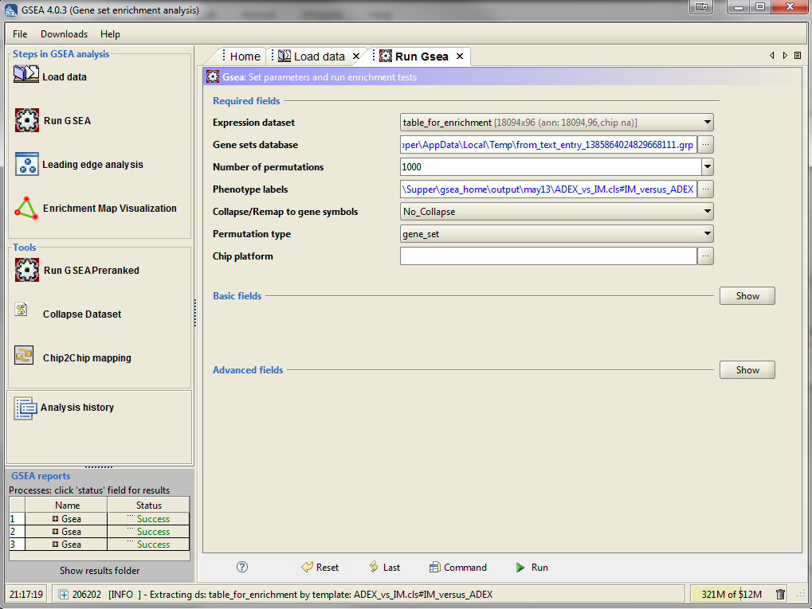

```python
Image(filename='img/gsea.png')
```

```python
# saving dataframe in order to use it in gsea
expression_dataframe.drop(columns='gene_name').to_csv("data/table_for_enrichment.txt", sep="\t", index = False)
```

```python
# taking samples for all subtypes
subtype_ad_samples = [sample for sample in annotation_table.loc[annotation_table.subtype == 'ADEX'].icgc_id]
subtype_im_samples = [sample for sample in annotation_table.loc[annotation_table.subtype == 'Immunogenic'].icgc_id]
subtype_sq_samples = [sample for sample in annotation_table.loc[annotation_table.subtype == 'Squamous'].icgc_id]
subtype_pp_samples = [sample for sample in
                      annotation_table.loc[annotation_table.subtype == 'Pancreatic Progenitor'].icgc_id]

# writing them into different files in order to use it in gsea
sub_lst = ['ADEX', 'Squamous', 'Immunogenic', 'Pancreatic Progenitor']
lists = [subtype_ad_samples, subtype_sq_samples, subtype_im_samples, subtype_im_samples]

for lst, subtype in zip(lists, sub_lst):
    subtype = subtype.lower()
    with open(f'data/samples_{subtype}.txt', 'w') as file:
        for sample in lst:
            file.write(sample + '\n')
```

- Построим гистограмму распределения разности средних в выборках по парам подтипов, чтобы выяснить, какую группу стоит взять для Enrichment Analysis:

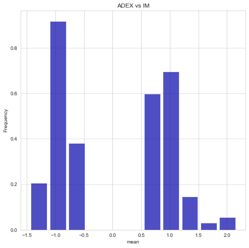

```python
# let's look at means
mean_res = []

# iterating for genes
for gene in genes_ad_im_normal:
    sample_type_ad = np.array(exp_T.loc[exp_T.subtype == 'ADEX'][gene])
    sample_type_im = np.array(exp_T.loc[exp_T.subtype == 'Immunogenic'][gene])
    mean_res.append(sample_type_ad.mean()-sample_type_im.mean())

# plotting
fig = plt.figure(figsize=(8,8))
prob_for_bins, bins, patches = plt.hist(x=mean_res, bins='auto', color='#0504aa',
                            alpha=0.7, rwidth=0.85, density=True)
plt.grid(axis='y', alpha=0.75)
plt.xlabel('mean')
plt.ylabel('Frequency')
plt.title('ADEX vs IM')
# Set a clean upper y-axis limit.
plt.show()
```

- На графике получилась яма в нуле - это свидетельствует о том, что статистические тесты сработали правильно и мы рассматриваем только гены, которые сильно отличаются по экспресии.
- Возьмём гены, различие средних экспрессий для подтипов ADEX и Immunogenic которых 1.5 и проведём enrichment analysis:

```python
# taking genes
gene_names = []

with open('data/genes_ad_im.txt', 'w') as file:
    for gene in genes_ad_im_normal:
        sample_type_ad = np.array(exp_T.loc[exp_T.subtype == 'ADEX'][gene])
        sample_type_im = np.array(exp_T.loc[exp_T.subtype == 'Immunogenic'][gene])
        if sample_type_ad.mean()-sample_type_im.mean() > 1.5:
            # taking name of the gene
            gene_names.append(expression_dataframe.loc[expression_dataframe.gene_id == gene].gene_name.values[0])
            file.write(gene + '\n')
```

```python
gene_names[:5]
```

```
['CPA1', 'AQP8', 'APLP1', 'SERPINI2', 'CLPS']
```

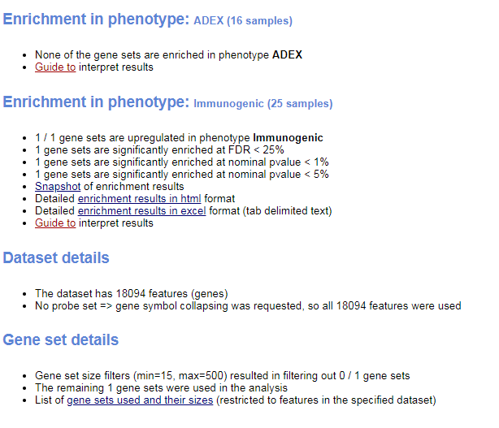

```python
Image(filename='img/gsea_results.png')
```

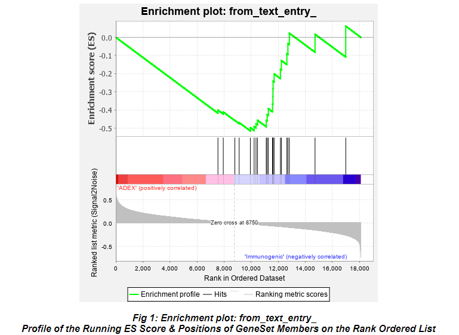

```python
Image(filename='img/gsea_res_pic.png')
```

- Почему-то GSEA выдаёт результат об насыщении этих генов в типе Immunogenic, хотя мы ждали совершенно обратного результата :(. Для остальных типов мы не будем проверять так как не понятно будет ли иметь смысл. Возможно много разных от факторов: от неправильной настройки GSEA до неправильных методов по борьбе с batch-effect.

### Analyzing patients

- Раздел по анализу данных пациентов, взятых из [статьи](https://www.nature.com/articles/nature16965#Sec44):

```python
# reading patients table
patients_data = pd.read_csv('data/humans.csv', sep=';')

# making subtypes column
col_subtype = [annotation_table.loc[annotation_table.icgc_id == sample].subtype.values[0] for sample in patients_data.icgc_id]

# inserting column
patients_data.insert(1, 'subtype', col_subtype)

patients_data.head()
```

|  | icgc_id | subtype | Sample type | qpure_score | qpure >40% | KRAS BY WTS or WES | KRAS by Deep Amplicon | EXOME | WGS | SNP | ... | Gender | Age at Diagnosis in Years | Country | Smoker | Tumour Grade | HistoSubtype | Tumour Location | AJCC Pathology Stage | Status | Length of Follow Up (months) |
| --- | --- | --- | --- | --- | --- | --- | --- | --- | --- | --- | --- | --- | --- | --- | --- | --- | --- | --- | --- | --- | --- |
| 0 | ICGC_0393 | Squamous | Primary tumour | 52 | YES | Y | Y | - | YES | YES | ... | Male | 60 | United States of America | Stopped Smoking | 3 - Poorly differentiated | PDA - Adenosquamous carcinoma | Head | IB | Alive - Without Disease | 2,8 |
| 1 | ICGC_0354 | ADEX | Primary tumour | 82 | YES | Y | Y | - | YES | YES | ... | Male | 49 | Australia | Still Smoking | 3 - Poorly differentiated | Pancreatic Ductal Adenocarcinoma | Head | IV | Deceased - Of Disease | 3,6 |
| 2 | ICGC_0392 | Squamous | Primary tumour | 58 | YES | Y | Y | - | YES | YES | ... | Male | 50 | United States of America | Not documented | 3 - Poorly differentiated | Pancreatic Ductal Adenocarcinoma | Head | IIB | Deceased - Of Disease | 10,9 |
| 3 | ICGC_0391 | ADEX | Primary tumour | 65 | YES | N | N | - | YES | YES | ... | Male | 64 | Australia | Never Smoked | 3 - Poorly differentiated | Acinar Cell Carcinoma | Head | IIB | Deceased - Of Disease | 15,8 |
| 4 | ICGC_0417 | Pancreatic Progenitor | Primary tumour | 54 | YES | Y | Y | - | YES | YES | ... | Male | 65 | Australia | Never Smoked | 2 - Moderately differentiated | Pancreatic Ductal Adenocarcinoma | Head | IIA | Alive - With Disease | 15,0 |

5 rows × 25 columns

#### Qpure_score

- Для начала сразу же проверим нормальность наших данных с помощью теста Шапиро:

```python
import statsmodels.stats.multicomp
```

```python
# taking rest subtypes
sam_ad = np.array(patients_data.loc[patients_data.subtype == 'ADEX'].qpure_score)
sam_sq = np.array(patients_data.loc[patients_data.subtype == 'Squamous'].qpure_score)
sam_im = np.array(patients_data.loc[patients_data.subtype == 'Immunogenic'].qpure_score)
sam_pp = np.array(patients_data.loc[patients_data.subtype == 'Pancreatic Progenitor'].qpure_score)

# preparing stuff for iterations
sub_lst = ['ADEX', 'Squamous', 'Immunogenic', 'Pancreatic Progenitor']
sub_it = it.combinations(sub_lst, 2)
cy_dict = {'ADEX': sam_ad, 'Squamous': sam_sq, 'Immunogenic': sam_im, 'Pancreatic Progenitor': sam_pp}
```

```python
# checking normality of our data
for sub in sub_lst:
    print(f'{sub} subtype Shapiro test:')
    print(stats.shapiro(cy_dict[sub]))
```

```
ADEX subtype Shapiro test:
(0.9531246423721313, 0.5407478213310242)
Squamous subtype Shapiro test:
(0.9648277759552002, 0.5186991095542908)
Immunogenic subtype Shapiro test:
(0.961713969707489, 0.44965943694114685)
Pancreatic Progenitor subtype Shapiro test:
(0.9585792422294617, 0.2847941219806671)
```

- Так как все наши данные про **Qpure_score** (процент содержания раковых клеток в образце биопсии) распределены нормально, мы можем использовать известные тесты для попраной проверки подтипов рака на статистически значимые отклонений:

```python
# tukey test
stat_res = statsmodels.stats.multicomp.pairwise_tukeyhsd(np.array(patients_data.qpure_score, dtype='float64'),patients_data.subtype)
table = stat_res.summary()
table
```

Multiple Comparison of Means - Tukey HSD, FWER=0.05

| group1 | group2 | meandiff | p-adj | lower | upper | reject |
| --- | --- | --- | --- | --- | --- | --- |
| ADEX | Immunogenic | -6.1375 | 0.4736 | -17.2246 | 4.9496 | False |
| ADEX | Pancreatic Progenitor | -2.0042 | 0.9 | -12.7246 | 8.7163 | False |
| ADEX | Squamous | -5.4575 | 0.5645 | -16.5446 | 5.6296 | False |
| Immunogenic | Pancreatic Progenitor | 4.1333 | 0.6396 | -5.2446 | 13.5112 | False |
| Immunogenic | Squamous | 0.68 | 0.9 | -9.1149 | 10.4749 | False |
| Pancreatic Progenitor | Squamous | -3.4533 | 0.7452 | -12.8312 | 5.9246 | False |

- Тест Тьюки не показал значительных отклонений распределения **Qpure_score** в разных подтипах рака.
- На всякий случай проверим это с помощью t-теста Стьюдента (для начала возьмём пару ADEX и Squamous):

```python
print(stats.bartlett(sam_ad, sam_sq))
```

```
BartlettResult(statistic=0.9356805532986253, pvalue=0.33339117411073665)
```

- Тест Бартлетта показал, что мы не можем отвергнуть гипотезу о равенстве дисперсий в двух взятых выборках. Поэтому будем считать, что они равны.

```python
# let's use Student's t-test
print(stats.ttest_ind(sam_ad, sam_sq, equal_var=True))
```

```
Ttest_indResult(statistic=1.2851824543621693, pvalue=0.20630864413228875)
```

```python
# iterating and doing Student's t-test
for sub_a, sub_b in sub_it:
    # taking data
    sub_1 = cy_dict[sub_a]
    sub_2 = cy_dict[sub_b]

    # calculating bartlett test
    bartlett = stats.bartlett(sub_1, sub_2)

    # checking p_value from bartlett test
    if bartlett[1] > 0.05:
        # if p_value from barlett is more than 0.05, we will use equal vars parameter in t-test
        equal_var=True
    else:
        # and vice-versa
        equal_var=False

    print(f'{sub_a} and {sub_b}: P-value = {stats.ttest_ind(sub_1, sub_2, equal_var=equal_var)[1]}')

# sorry for such big print
```

```
ADEX and Squamous: P-value = 0.20630864413228875
ADEX and Immunogenic: P-value = 0.15493628185363012
ADEX and Pancreatic Progenitor: P-value = 0.6571211368403069
Squamous and Immunogenic: P-value = 0.8416965569167572
Squamous and Pancreatic Progenitor: P-value = 0.3400801786852473
Immunogenic and Pancreatic Progenitor: P-value = 0.2531731422488433
```

- Наконец проверим **ANOVA** для всех выборок сразу:

```python
# at last let's check anova

anova = stats.f_oneway(sam_ad, sam_im, sam_sq, sam_pp)
print(anova)
```

```
F_onewayResult(statistic=1.0102085165333352, pvalue=0.3919541377306284)
```

**Вывод:** Таким образом, по полученным данным, мы не можем утверждать, что есть какие-либо статистически значимые отклонения в показателе **Qpure_score** для исследуемых подтипов рака (ни попарно, ни у всех вместе сразу).

### Anlysis by Gender

- Для анализа по Gender будем считать, что в каждом из подтипов распределение 'Male' и 'Female' - это Биномиальное распределение, где, например, 'Female' - успех, а 'Male' - неудача :)
- Наша гипотеза для двух независимых выборок $H_0: p_1 = p_2$ (где $p_1$ и $p_2$ вероятности успеха для двух биномиальных распределений).
- Используем следующую статистику критерия: \begin{equation}z=\frac{\hat{p}_{1}-\hat{p}_{2}}{\sqrt{\hat{p}(1-\hat{p})\left(\frac{1}{n_{1}}+\frac{1}{n_{2}}\right)}}\end{equation}  
  , где \begin{equation}\hat{p_i}=\frac{k_i}{n_i}\end{equation} \begin{equation}\hat{p}=\frac{n_{1} \hat{p}_{1}+n_{2} \hat{p}_{2}}{n_{1}+n_{2}}\end{equation}
- Данная статистика будет иметь нормальное распределение.

```python
# dict to convert gender into success-fail
dict_succ = {'Female': 1, 'Male': 0}
# taking data from out patients dataframe
samples_gender_ad = np.array([dict_succ[gender] for gender
                              in patients_data.loc[patients_data.subtype == 'ADEX']['Gender']])
samples_gender_sq = np.array([dict_succ[gender] for gender
                              in patients_data.loc[patients_data.subtype == 'Squamous']['Gender']])
samples_gender_im = np.array([dict_succ[gender] for gender
                              in patients_data.loc[patients_data.subtype == 'Immunogenic']['Gender']])
samples_gender_pp = np.array([dict_succ[gender] for gender
                              in patients_data.loc[patients_data.subtype == 'Pancreatic Progenitor']['Gender']])
```

```python
def binom_analyze(a, b):
    """
    Function to analyze hypothesis for two groups from binominal dist
    """
    # calculating parameters of binominal dist
    n_1 = len(a)
    n_2 = len(b)
    p_1 = sum(a)/n_1
    p_2 = sum(b)/n_2

    # calculating p with formula above
    p = (n_1*p_1 + n_2*p_2)/(n_1 + n_2)

    # calculating statistic
    z = (p_1 - p_2)/np.sqrt(p*(1-p)*(1/n_1 + 1/n_2))

    # finding out two-sided (because of normal dist) p_value
    p_value = min(stats.norm.cdf(z), 1-stats.norm.cdf(z))

    return p_value
```

```python
# preparing stuff for iterations
sub_lst = ['ADEX', 'Squamous', 'Immunogenic', 'Pancreatic Progenitor']
sub_it = it.combinations(sub_lst, 2)
cy_dict_gender = {'ADEX': samples_gender_ad, 'Squamous': samples_gender_sq,
                  'Immunogenic': samples_gender_im, 'Pancreatic Progenitor': samples_gender_pp}

for sub_a, sub_b in sub_it:
    sub_1 = cy_dict_gender[sub_a]
    sub_2 = cy_dict_gender[sub_b]

    print(f'P-value for {sub_a} and {sub_b}: {binom_analyze(sub_1, sub_2)}')
```

```
P-value for ADEX and Squamous: 0.4502712007885079
P-value for ADEX and Immunogenic: 0.45027120078850785
P-value for ADEX and Pancreatic Progenitor: 0.41466669551635604
P-value for Squamous and Immunogenic: 0.38864870539476065
P-value for Squamous and Pancreatic Progenitor: 0.46071999108484574
P-value for Immunogenic and Pancreatic Progenitor: 0.34680606328505337
```

```python
# at last let's check anova

anova = stats.f_oneway(samples_gender_ad, samples_gender_sq, samples_gender_im, samples_gender_pp)
print(anova)
```

```
F_onewayResult(statistic=0.05496009651076467, pvalue=0.982938131897464)
```

- **Вывод**: было показано, что при использовании биномиального распределения и выбраной статистики гипотезу о том, что разные подтипы рака с одиннаковой вероятностью поражают и мужчин, и женщин, отвергать нельзя.

### Ethnicity

- Анализ типов рака по этнической принадлежности.
- Сначала посчитаем качественный состав выборок:

```python
# lets take samples
all_samples = patients_data['Ethnicity']
samples_eth_ad = patients_data.loc[patients_data.subtype == 'ADEX']['Ethnicity']
samples_eth_sq = patients_data.loc[patients_data.subtype == 'Squamous']['Ethnicity']
samples_eth_im = patients_data.loc[patients_data.subtype == 'Immunogenic']['Ethnicity']
samples_eth_pp = patients_data.loc[patients_data.subtype == 'Pancreatic Progenitor']['Ethnicity']
```

```python
# calculating procents of White/Caucasian, Asian and nor White/Caucasian nor Asian
lst = [all_samples, samples_eth_ad, samples_eth_sq, samples_eth_im, samples_eth_pp]
lst_names = ['All', 'ADEX', 'SQ', 'IM', 'PP']
for ser, name in zip(lst, lst_names):
    white = list(ser).count('White/Caucasian')/len(list(ser))*100
    asian = list(ser).count('Asian')/len(list(ser))*100
    minor = 100 - white - asian
    print(f'{name}: white - {white}%, asian - {asian}%, not white or asian - {minor}%')
```

```
All: white - 86.45833333333334%, asian - 8.333333333333332%, not white or asian - 5.208333333333325%
ADEX: white - 100.0%, asian - 0.0%, not white or asian - 0.0%
SQ: white - 88.0%, asian - 8.0%, not white or asian - 4.0%
IM: white - 84.0%, asian - 8.0%, not white or asian - 8.0%
PP: white - 80.0%, asian - 13.333333333333334%, not white or asian - 6.666666666666666%
```

- Так как анализы в большинстве своём проводились на белых людях (86\% White/Caucasian этнической принадлежности для всей выборки и для групп: 100\% - из 16 пациентов с 'ADEX', 88\% - из 25 пациентов с 'Squamous', 84\% - из 25 пациентов с 'Immunogenic', 80\% - из 30 пациентов с 'Pancreatic Progenitor'), то считаю, что проводить анализ "Cancer subtype from Ethnicity" нельзя из-за плохой репрезентативности (и малого размера в том числе) исследуемых выборок.

Note: конечно, можно было провести какой-нибудь тест и показать, что этносы отличающееся от White/Caucasian больше болеют Pancreatic Progenitor и меньше ADEX, но боюсь, такой анализ привёл бы нас к ложным выводам.

### Age at Diagnosis in Years

- Для начала построим гистограмму для всех пациентов и для пациентов каждого подтипа рака отдельно, чтобы посмотреть распределение по возрасту:

```python
# lets take samples
all_patients_years = list(patients_data['Age at Diagnosis in Years'])
samples_years_ad = patients_data.loc[patients_data.subtype == 'ADEX']['Age at Diagnosis in Years']
samples_years_sq = patients_data.loc[patients_data.subtype == 'Squamous']['Age at Diagnosis in Years']
samples_years_im = patients_data.loc[patients_data.subtype == 'Immunogenic']['Age at Diagnosis in Years']
samples_years_pp = patients_data.loc[patients_data.subtype == 'Pancreatic Progenitor']['Age at Diagnosis in Years']
```

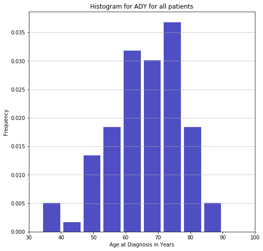

```python
fig = plt.figure(figsize=(8,8))
prob_for_bins, bins, patches = plt.hist(x=all_patients_years, bins='auto', color='#0504aa',
                            alpha=0.7, rwidth=0.85, density=True)
plt.grid(axis='y', alpha=0.75)
plt.xlabel('Age at Diagnosis in Years')
plt.ylabel('Frequency')
plt.title('Histogram for ADY for all patients')
maxfreq = prob_for_bins.max()
# Set a clean upper y-axis limit.
plt.ylim()
plt.xlim(30, 100)
plt.show()
```

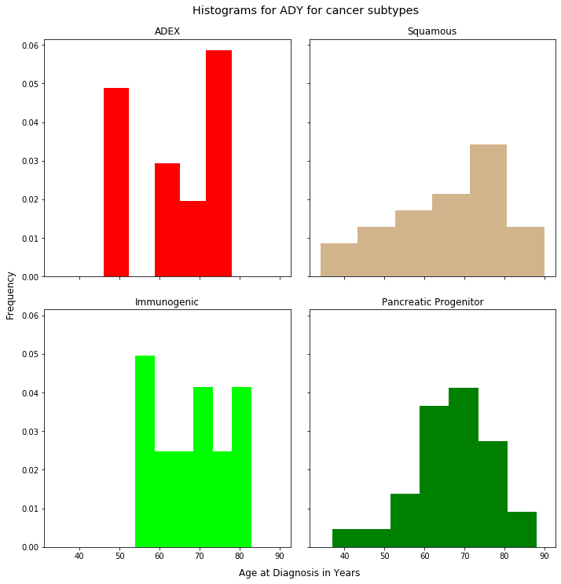

```python
fig, ((ax0, ax1), (ax2, ax3)) = plt.subplots(nrows=2, ncols=2, figsize=(10,10), sharex=True, sharey=True)

colors = ['red', 'tan', 'lime', 'green']
ax0.hist(samples_years_ad, bins='auto', density=True, color=colors[0], label=colors)
ax0.set_title('ADEX')

ax1.hist(samples_years_sq, bins='auto', density=True, color=colors[1], label=colors)
ax1.set_title('Squamous')

ax2.hist(samples_years_im, bins='auto', density=True, color=colors[2], label=colors)
ax2.set_title('Immunogenic')

ax3.hist(samples_years_pp, bins='auto', density=True, color=colors[3], label=colors)
ax3.set_title('Pancreatic Progenitor')

fig.text(0.52, 0.0, 'Age at Diagnosis in Years', ha='center', size='large')
fig.text(0.0, 0.5, 'Frequency', va='center', rotation='vertical', size='large')
fig.tight_layout(pad=2)
fig.text(0.33, 1, 'Histograms for ADY for cancer subtypes', va='center', size='x-large')
plt.show()
```

- Проверим тест Крускала для всех подтипа и тест Манна-Уитни для пары:

```python
stats.kruskal(samples_years_ad, samples_years_sq, samples_years_im, samples_years_pp)
```

```
KruskalResult(statistic=1.043134645598858, pvalue=0.7908162195186238)
```

```python
stats.mannwhitneyu(samples_years_ad, samples_years_sq)
```

```
MannwhitneyuResult(statistic=177.0, pvalue=0.27359793295977625)
```

- Хотя по гистограмам легко увидеть, что для разных типов рака характерны различные распределения возрастов (и разные параметры), однако непараметрические статистические тесты, которые мы использовали показывают, что p-value > 0.05. Скорее всего для доказательства того, что возрасты распределены по-разному нужен более чувствительный тест, также большую роль могут играть маленьки размеры выборок.

### KRAS mutations

- Для того, чтобы определить, различаются ли подтипы рака поджелудочной железы по частоте мутации гена KRAS используем такой же подход, как и при анализе гендерных различий между подтипами, т.е. биномиальное распределение и формулу, приведенную выше:

```python
all_patients = patients_data['KRAS BY WTS or WES']

# dict to convert gender into success-fail
dict_success = {'Y': 1, 'N': 0}
# taking data from out patients dataframe
samples_kras_ad = np.array([dict_success[mut] for mut in
                            patients_data.loc[patients_data.subtype == 'ADEX']['KRAS BY WTS or WES']])
samples_kras_sq = np.array([dict_success[mut] for mut in
                            patients_data.loc[patients_data.subtype == 'Squamous']['KRAS BY WTS or WES']])
samples_kras_im = np.array([dict_success[mut] for mut in
                            patients_data.loc[patients_data.subtype == 'Immunogenic']['KRAS BY WTS or WES']])
samples_kras_pp = np.array([dict_success[mut] for mut in
                            patients_data.loc[patients_data.subtype == 'Pancreatic Progenitor']['KRAS BY WTS or WES']])
```

```python
# preparing stuff for iterations
sub_lst = ['ADEX', 'Squamous', 'Immunogenic', 'Pancreatic Progenitor']
sub_it = it.combinations(sub_lst, 2)
cy_dict_kras = {'ADEX': samples_kras_ad, 'Squamous': samples_kras_sq,
                'Immunogenic': samples_kras_im, 'Pancreatic Progenitor': samples_kras_pp}

for sub_a, sub_b in sub_it:
    sub_1 = cy_dict_kras[sub_a]
    sub_2 = cy_dict_kras[sub_b]

    print(f'P-value for {sub_a} and {sub_b}: {binom_analyze(sub_1, sub_2)}')
```

```
P-value for ADEX and Squamous: 0.004248344236503328
P-value for ADEX and Immunogenic: 0.2390526926463573
P-value for ADEX and Pancreatic Progenitor: 0.08866972000925571
P-value for Squamous and Immunogenic: 0.01852810928205939
P-value for Squamous and Pancreatic Progenitor: 0.05196322543587162
P-value for Immunogenic and Pancreatic Progenitor: 0.25308794944041213
```

- По итогам такого анализа оказалось, что подтип Squamous статистически значимо отличается от подтипов ADEX и Immunogenic. Cтоит также обратить внимание на пары ADEX - PP, Squamous - PP.
- Проверим различия в экспресии:

```python
# making kras_df
kras_exp = expression_dataframe.loc[expression_dataframe.gene_name == 'KRAS'].drop(columns=['gene_id', 'gene_name']).transpose()
kras_exp.reset_index(inplace=True)
kras_exp = kras_exp.rename(columns={'index': 'sample', 6032: 'exp'})
kras_exp.sample = expression_dataframe.columns[2:]
```

```python
# for subtypes
kras_ad = [kras_exp.loc[kras_exp.sample == sample].exp.values[0] for sample in subtype_ad_samples]
kras_sq = [kras_exp.loc[kras_exp.sample == sample].exp.values[0] for sample in subtype_sq_samples]
kras_im = [kras_exp.loc[kras_exp.sample == sample].exp.values[0] for sample in subtype_im_samples]
kras_pp = [kras_exp.loc[kras_exp.sample == sample].exp.values[0] for sample in subtype_pp_samples]
```

```python
# let's go
# Kruskal at first
print(f'Kruskal: {stats.kruskal(kras_ad, kras_sq, kras_im, kras_pp)[1]}')

# let's do by pairs
cy_dict_kras = {'ADEX': kras_ad, 'Squamous': kras_sq,
                'Immunogenic': kras_im, 'Pancreatic Progenitor': kras_pp}
sub_it = it.combinations(sub_lst, 2)

for sub_1, sub_2 in sub_it:
    sam_1 = cy_dict_kras[sub_1]
    sam_2 = cy_dict_kras[sub_2]
    print(f'P-value for {sub_1} and {sub_2}: {stats.mannwhitneyu(sam_1, sam_2)[1]}')
```

```
Kruskal: 0.4277254792122006
P-value for ADEX and Squamous: 0.05897007201457901
P-value for ADEX and Immunogenic: 0.17136691705139345
P-value for ADEX and Pancreatic Progenitor: 0.11746419957115578
P-value for Squamous and Immunogenic: 0.18605416539590774
P-value for Squamous and Pancreatic Progenitor: 0.34560169590540424
P-value for Immunogenic and Pancreatic Progenitor: 0.3518541627940925
```

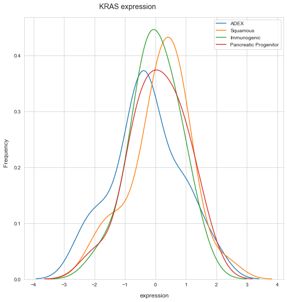

```python
from scipy.stats import gaussian_kde
import seaborn as sns
#sns.set_style('whitegrid')

fig  = plt.figure(figsize=(8, 8))

colors = ['red', 'tan', 'lime', 'green']
for color, sub in zip(colors, sub_lst):
    data = cy_dict_kras[sub]
    sns.kdeplot(np.array(data), bw=0.5, label=sub)


fig.text(0.52, 0.0, 'expression', ha='center', size='large')
fig.text(0.0, 0.5, 'Frequency', va='center', rotation='vertical', size='large')
fig.tight_layout(pad=2)
fig.text(0.33, 1, 'KRAS expression', va='center', size='x-large')
plt.legend()
plt.show()
```

- По графику заметно, что экспресия гена KRAS в типах Immunogenic и Pancreatic Progenitor имеет нормально-подобное распределение с нулевым средним, тогда как в распределениях для типлв ADEX и Squamous появились хвосты и изменение среднего и медианы относительно нуля. Изначально именно для подтипа ADEX заявлялось изменение экспресии гена KRAS.

### Выживаемость

- Проверим различаются ли выборки пациентов для подтипов рака поджелудочной железы по выживаемости пациентов. Для этого сначала возьмём пациентов, которые не выжили и проверим с помощью теста Манна-Уитни гипотезу: распределение смертей по времени не отличается для пар выборок:

**Note**: Для данного анализа недостаточно столбца "«Length of Follow Up (months)", потому что также нужна информация о лечении и о тяжести состояния пациента при обнаружении рака.

```python
# let's take part of our patient dataframe

surv_df = patients_data[['icgc_id', 'subtype', 'Status', 'Length of Follow Up (months)']]
```

```python
# dict for changing status column
surv_dict = {'Deceased - Of Unknown Cause': -2, 'Deceased - Of Other Cause': -1,
             'Deceased - Of Disease': 0, 'Alive - With Disease': 1, 'Alive - Without Disease': 2}

# converting status using dict
surv_df.insert(2, 'status', [surv_dict[sample] for sample in surv_df.Status])
surv_df = surv_df.drop(columns='Status')

# converting Length of Follow Up (months) to float type
surv_df.insert(3, 'length_time_month', [float(length.replace(',', '.')) for length in
                                        surv_df['Length of Follow Up (months)']])
surv_df = surv_df.drop(columns='Length of Follow Up (months)')

surv_df.head()
```

|  | icgc_id | subtype | status | length_time_month |
| --- | --- | --- | --- | --- |
| 0 | ICGC_0393 | Squamous | 2 | 2.8 |
| 1 | ICGC_0354 | ADEX | 0 | 3.6 |
| 2 | ICGC_0392 | Squamous | 0 | 10.9 |
| 3 | ICGC_0391 | ADEX | 0 | 15.8 |
| 4 | ICGC_0417 | Pancreatic Progenitor | 1 | 15.0 |

```python
# taking data
group_im = surv_df.loc[surv_df.subtype == 'Immunogenic']
group_pp = surv_df.loc[surv_df.subtype == 'Pancreatic Progenitor']
group_ad = surv_df.loc[surv_df.subtype == 'ADEX']
group_sq = surv_df.loc[surv_df.subtype == 'Squamous']
```

```python
# taking only dead patients
death_times_pp = group_pp.loc[group_pp.status <= 0].length_time_month.to_numpy()
death_times_sq = group_sq.loc[group_sq.status <= 0].length_time_month.to_numpy()
death_times_ad = group_ad.loc[group_ad.status <= 0].length_time_month.to_numpy()
death_times_im = group_im.loc[group_im.status <= 0].length_time_month.to_numpy()
```

```python
sub_lst = ['ADEX', 'Squamous', 'Immunogenic', 'Pancreatic Progenitor']
sub_it = it.combinations(sub_lst, 2)
cy_dict_kras = {'ADEX': death_times_ad, 'Squamous': death_times_sq, 'Immunogenic': death_times_im,
                'Pancreatic Progenitor': death_times_pp}

for sub_a, sub_b in sub_it:
    sub_1 = cy_dict_kras[sub_a]
    sub_2 = cy_dict_kras[sub_b]

    print(f'P-value for {sub_a} and {sub_b}: {stats.mannwhitneyu(sub_1, sub_2)[1]}')
```

```
P-value for ADEX and Squamous: 0.0774329244783227
P-value for ADEX and Immunogenic: 0.2332605822066195
P-value for ADEX and Pancreatic Progenitor: 0.43336552969651665
P-value for Squamous and Immunogenic: 0.35773338010812505
P-value for Squamous and Pancreatic Progenitor: 0.07443324938575442
P-value for Immunogenic and Pancreatic Progenitor: 0.21897195953068416
```

- При пороге p-value = 0.05, тест Манна-Уитни не выявил различий между выборками, однако наименьшие результаты p-value были для пар Squamous-ADEX и Squamous-Pancreatic Progenitor, повторно проверим различия с помощью кривой Каплана-Мейера уже учитывая так же вылечившихся пациентов.

### Kaplan-Meier curve

- **Метод Каплана-Мейера** - непараметрический метод оценивания кривой выживаемости по полученной выборке. Кривая выживаемости представляет собой следующее:

\begin{equation}\mathbf{S}(T)=P(T>t)=1-F(T)\end{equation}

, где $F(t)$ - функция распределения от времени. Таким образом кривая выживаемости показывает вероятность пациента выжить в данный промежуток времени. По методу Каплана-Мейера кривая выживаемости считается по следующей формуле:

\begin{equation}\hat{S}(t)=\prod_{i: t_{i} \leq t} \frac{n_{i}-d_{i}}{n_{i}}\end{equation}

, где $n_i$ - количество человек, находящихся под риском перед временем $t_i$, а $d_i$ - количество смертей, случившихся при времени $t_i$. Цензурированные пациенты (т.е. пациенты вылечившиеся во время исследования) не попадают в $d_i$.

**Алгоритм построения**:

- Для построения кривой Каплана-Мейера используем следующий алгоритм:
  - В момент времени $t = 0$: $\hat{S}(t) = 1$
  - Используем for-loop по всем событиям сортированным по length_time_month:
    - Если прозошло $k$-количесто смертей, изменяем $\hat{S}$ в соответствии с формулой
    - Если произошло $l$-количество цензурирований, то оставляем $\hat{S}$ без изменений
    - На каждом шаге сохраняем $t$ и $\hat{S}$ в массивах
  - Построение с помощью matplotlib
- Похожий алгоритм реализован в библиотеке lifelines. Сначала мы сами построим кривую Каплана-Мейера и проверим, сходится ли она с той, что строится с помощью функции из библиотеки. В дальнейшем будем пользоваться библиотекой lifelines, т.к. там более информативные графики.

```python
# using lifelines
from lifelines import KaplanMeierFitter

# plotting KM
kmf = KaplanMeierFitter()
```

```python
# small function
def status_convert(pd_ser):
    res = []
    for x in pd_ser:
        if x > 0:
            res.append(0)
        else:
            res.append(1)

    return np.array(res)
```

```python
# taking data
time_1 = np.array(group_im['length_time_month'])
surv_1 = status_convert(group_im['status'])
time_2 = np.array(group_sq['length_time_month'])
surv_2 = status_convert(group_sq['status'])
time_3 = np.array(group_ad['length_time_month'])
surv_3 = status_convert(group_ad['status'])
time_4 = np.array(group_pp['length_time_month'])
surv_4 = status_convert(group_pp['status'])
```

```python
# our function to construct KMC
def construct_kmc(df):
    """
    Function to construct Kaplan-Meier curve
    """
    # sorting df according to time (followed)
    sorted_df = df.sort_values(by=['length_time_month'])

    # taking columns
    time_occ = np.array(sorted_df['length_time_month'])
    status = np.array(sorted_df['status'])

    # list where to save time and probability + starting positions
    t_res = [0]
    surv_prob = [1, 1]

    # making tmp list for time
    # because our code is, I would say, de_optimized as hell (-_-)
    tmp_time = time_occ

    for t in time_occ:

        # appending time
        t_res.append(t)

        # number of events with time >= t
        n = len(tmp_time[tmp_time >= t])

        # id_ for taking slices
        id_ = len(tmp_time[tmp_time <= t])

        # taking part of patients from status
        tmp = status[:id_]

        # taking only those who is dead :(
        d = len(tmp[tmp <= 0])

        # break part for the end of algorithm
        if n == 1 or n == 0:
            #surv_prob.append(surv_prob[-1])
            break

        # making S(t) according to the last S(t_before)
        if d == 0:
            # if no death occured S(t) would not change
            surv_prob.append(surv_prob[-1])
        else:
            # changing if there were deaths
            surv_prob.append(surv_prob[-1]*(n-d)/(n))

        # just taking patients that we will need further
        status = status[id_:]
        tmp_time = tmp_time[id_:]
    return surv_prob, t_res
```

- Построим кривую КМ для подтипа Immunogenic с помощью нашей функции и с помощью функции из библиотеки lifelines:

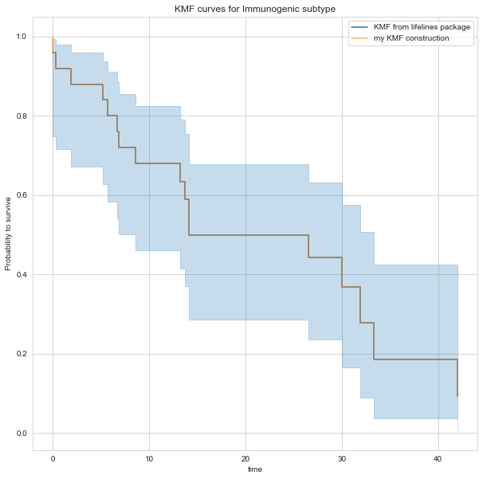

```python
y, x = construct_kmc(group_im)

fig = plt.figure(figsize=(10,10))

kmf.fit(time_1, surv_1, label="KMF from lifelines package").plot()
plt.step(x, y, label="my KMF construction", alpha=0.6)
plt.legend()
plt.xlabel('time')
plt.ylabel('Probability to survive')
plt.title('KMF curves for Immunogenic subtype')

plt.show()
```

- Данные графики совпали друг с другом, что означает, наша функция работает правильно.
- Построим кривые К-М для всех подтипов рака:

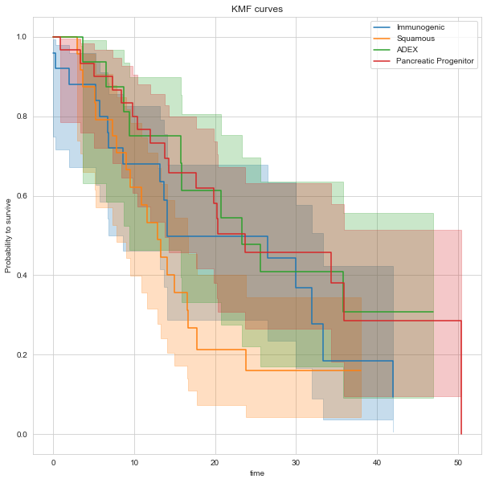

```python
fig = plt.figure(figsize=(10,10))

kmf.fit(time_1, surv_1, label="Immunogenic").plot()
kmf.fit(time_2, surv_2, label="Squamous").plot()
kmf.fit(time_3, surv_3, label="ADEX").plot()
kmf.fit(time_4, surv_4, label="Pancreatic Progenitor").plot()
plt.xlabel('time')
plt.ylabel('Probability to survive')
plt.title('KMF curves')

plt.show()
```

- Самый крутой график получился для подтипа Squamous, таким образом мы показали, что именно при выявление такого подтипа рака поджелудочной, прогноз для пациента очень плохой.
- Проверим, на всякий случай, наше утверждение о Squmous с помощью longrank-теста:

```python
#logrank_test
from lifelines.statistics import logrank_test

sub_lst = ['ADEX', 'Squamous', 'Immunogenic', 'Pancreatic Progenitor']
sub_it = it.combinations(sub_lst, 2)
cy_dict_kmp = {'ADEX': (time_3, surv_3), 'Squamous': (time_2, surv_2), 'Immunogenic': (time_1, surv_1), 'Pancreatic Progenitor': (time_4, surv_4)}

for sub_a, sub_b in sub_it:
    time_one, surv_one = cy_dict_kmp[sub_a]
    time_two, surv_two = cy_dict_kmp[sub_b]

    result_lg = logrank_test(time_one, time_two, event_observed_A=surv_one, event_observed_B=surv_two)

    p_value = result_lg.p_value

    print(f'P-value for {sub_a} and {sub_b}: {p_value}')
```

```
P-value for ADEX and Squamous: 0.05379656115176892
P-value for ADEX and Immunogenic: 0.3266636762012196
P-value for ADEX and Pancreatic Progenitor: 0.9386690633600604
P-value for Squamous and Immunogenic: 0.1630766416895128
P-value for Squamous and Pancreatic Progenitor: 0.019181146264847373
P-value for Immunogenic and Pancreatic Progenitor: 0.26111932797637966
```

- Именно пары с подтипом Squamous имеет наименьшие значения p-value среди всех пар